# Empirical logit plots

## Function

The following R function can be used to create empirical logit plots:

```r
logodds_plot <- function(data, num_bins, bin_method,
                         x_name, y_name, grouping = NULL,
                         reg_formula = y ~ x){

  if(is.null(grouping)){
    dat <- data.frame(x = data %>% pull(x_name),
                      y = data %>% pull(y_name),
                      group = 1)
  } else {
    dat <- data.frame(x = data %>% pull(x_name),
                      y = data %>% pull(y_name),
                      group = as.factor(data %>% pull(grouping)))
  }

  if(bin_method == "equal_size"){
    logodds_table <- dat %>%
      drop_na() %>%
      arrange(group, x) %>%
      group_by(group) %>%
      mutate(obs = y,
             bin = rep(1:num_bins,
                       each=ceiling(n()/num_bins))[1:n()]) %>%
      group_by(bin, group) %>%
      summarize(mean_x = mean(x),
                prop = mean(c(obs, 0.5)),
                num_obs = n()) %>%
      ungroup() %>%
      mutate(logodds = log(prop/(1 - prop)))
  } else {
    logodds_table <- dat %>%
      drop_na() %>%
      group_by(group) %>%
      mutate(obs = y,
             bin = cut(x,
                       breaks = num_bins,
                       labels = F)) %>%
      group_by(bin, group) %>%
      summarize(mean_x = mean(x),
                prop = mean(c(obs, 0.5)),
                num_obs = n()) %>%
      ungroup() %>%
      mutate(logodds = log(prop/(1 - prop)))
  }

  if(is.null(grouping)){
    logodds_table %>%
      ggplot(aes(x = mean_x,
                 y = logodds)) +
      geom_point(size=2) +
      geom_smooth(se=F, method="lm", formula = reg_formula) +
      theme_bw() +
      labs(x = x_name,
           y = "Empirical log odds") +
      theme(text = element_text(size=15))
  } else {
    logodds_table %>%
      ggplot(aes(x = mean_x,
                 y = logodds,
                 color = group,
                 shape = group)) +
      geom_point(size=2) +
      geom_smooth(se=F, method="lm", formula = reg_formula) +
      theme_bw() +
      labs(x = x_name,
           y = "Empirical log odds",
           color = grouping,
           shape = grouping) +
      theme(text = element_text(size=15))
  }

}
```

## Arguments

- `data`: the dataset of interest (e.g., `titanic`)
- `num_bins`: the number of bins to use
  - The number of bins should be chosen based on the size of the data. For example, with `bin_method = "equal_size"`, we probably want at least 15 observations per bin, so `num_bins` < (number of observations)/15
- `bin_method`: whether to choose bins with the same number of observations (`"equal_size"`) or the same width (`"equal_width"`)
- `x_name`: the name of the column containing the explanatory variable (e.g., `"Fare"`). The quotation marks are needed
- `y_name`: the name of the column containing the response (e.g., `"Survived"`). The quotation marks are needed
- `grouping`: the name of a categorical variable in the data; fit a separate line for each level of the categorical variable
- `reg_formula`: This is the shape of the relationship you want to plot. If you want a line, this is y ~ x (the default). Some other examples:
  - `y ~ log(x)` : a log transformation of x
  - `y ~ sqrt(x)` : a square root transformation of x
  - `y ~ poly(x, 2)` : a second-order polynomial
  - `y ~ poly(x, 3)` : a third-order polynomial

## Examples

The `titanic` dataset contains a number of variables recorded for passengers on the *Titanic* when it sunk on its first voyage. The `titanic` dataset can be loaded into R with

```r
titanic <- read.csv("https://sta214-f22.github.io/labs/Titanic.csv")
```

Now let’s see how to make empirical logit plots.

### Looking at Fare

The response variable we care about with the `titanic` data is `Survived`: whether a passenger survived the disaster or not. Let’s first look at `Fare` as an explanatory variable. We will make an empirical logit plot with 30 equally sized bins:

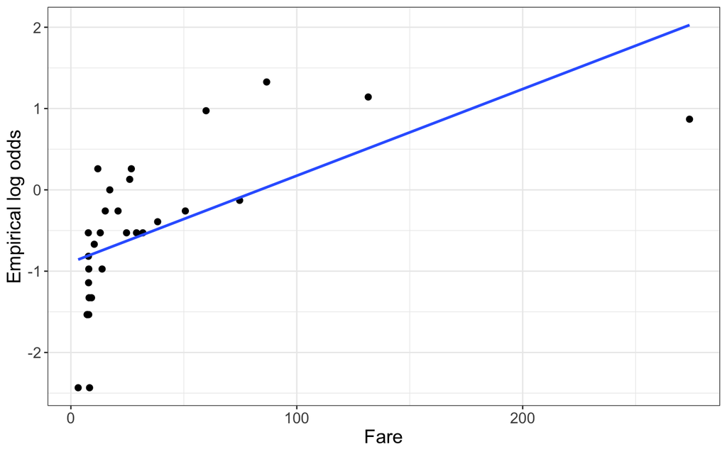

```r
library(tidyverse)
logodds_plot(titanic, 30, "equal_size", "Fare", "Survived",
             reg_formula = y ~ x)
```

### Trying a different shape

That linear fit doesn’t look very good! Maybe we should try a different shape. Let’s try a quadratic fit instead:

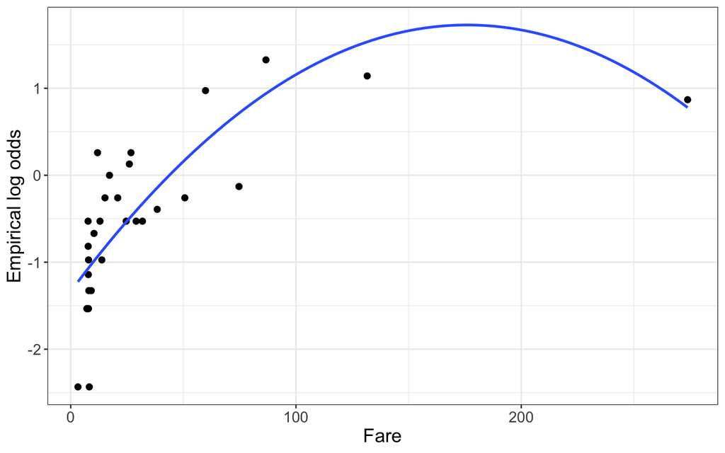

```r
logodds_plot(titanic, 30, "equal_size", "Fare", "Survived",
             reg_formula = y ~ poly(x, 2))
```

And maybe a log transformation too:

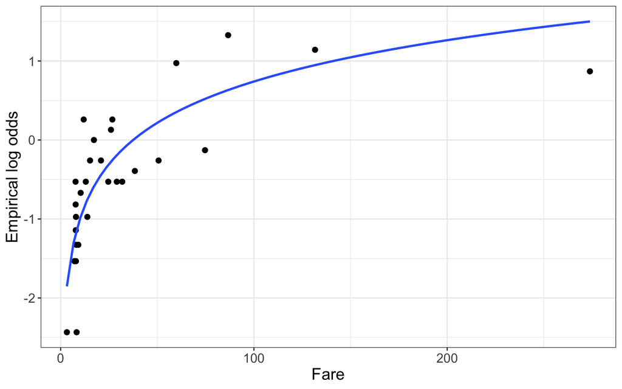

```r
logodds_plot(titanic, 30, "equal_size", "Fare", "Survived",
             reg_formula = y ~ log(x))
```

### Potential interactions

Does the relationship between Fare and Survival depend on passenger class (`Pclass`)? We can add `Pclass` as a grouping variable to the empirical logit plot, and fit a different line for each passenger class.

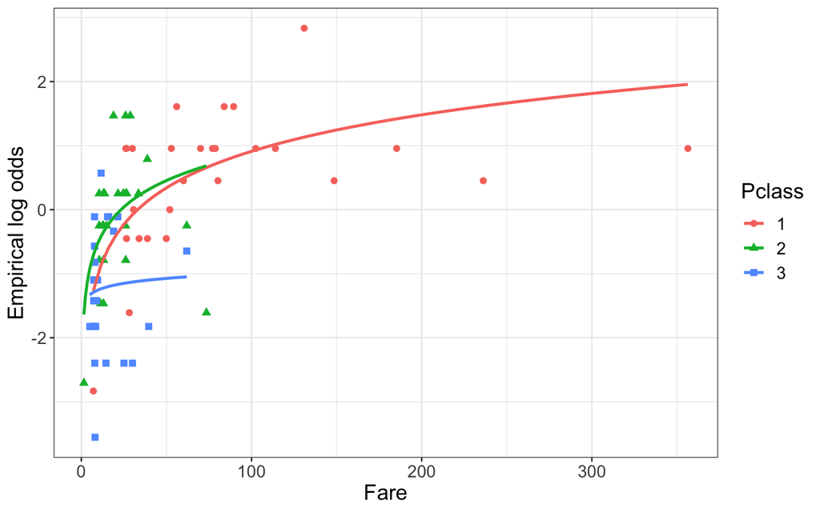

```r
logodds_plot(titanic, 30, "equal_size", "Fare", "Survived",
             grouping = "Pclass",
             reg_formula = y ~ log(x))
```

Now, this doesn’t let us see the relationship very well. Let’s transform Fare first, then make the empirical logit plot with the transformed variable:

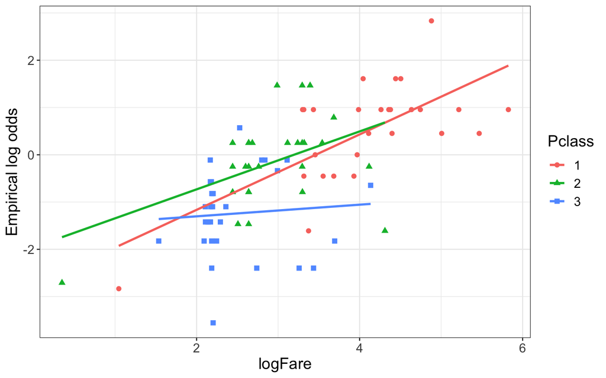

```r
titanic %>%
  mutate(logFare = log(Fare + 1)) %>%
  logodds_plot(30, "equal_size", "logFare", "Survived",
             grouping = "Pclass",
             reg_formula = y ~ x)
```

If we think these lines have different slopes, we might consider adding an interaction between Fare and passenger class.